# bike

```python
import pandas as pd
import numpy as np
import matplotlib.pyplot as plt
import matplotlib.dates as mdates
```

```python
weather_raw_df = pd.read_csv('NOAA_SF_weather.csv')
bike_df = pd.read_csv('2017-fordgobike-tripdata.csv')
for year in ['2018','2019']:
    for mth in ['01','02','03','04','05','06','07','08','09','10','11','12']:
        if year == '2019' and mth in ['05','06','07','08','09','10','11','12']:
            tmp_df = pd.read_csv(year+mth+'-baywheels-tripdata.csv')
        else:
            tmp_df = pd.read_csv(year+mth+'-fordgobike-tripdata.csv')
        bike_df = pd.concat([bike_df,tmp_df])
```

```python
# check for missing data, 2/28/2018 data is missing.
print (len(weather_daily))
print (len(weather_daily[weather_daily['DAILYAverageDryBulbTemp'].isnull()]))
print (len(weather_daily[weather_daily['DAILYDeptFromNormalAverageTemp'].isnull()]))
print (len(weather_daily[weather_daily['DAILYPrecip'].isnull()]))
print (len(weather_daily[weather_daily['DAILYHeatingDegreeDays'].isnull()]))
print (len(weather_daily[weather_daily['DAILYCoolingDegreeDays'].isnull()]))
weather_daily[weather_daily['DAILYAverageDryBulbTemp'].isnull()]
```

```
508
1
1
1
1
1
```

|  | DATE | DAILYAverageDryBulbTemp | DAILYDeptFromNormalAverageTemp | DAILYPrecip | DAILYHeatingDegreeDays | DAILYCoolingDegreeDays | day |
| --- | --- | --- | --- | --- | --- | --- | --- |
| 966 | 2018-02-28 23:59 | NaN | NaN | NaN | NaN | NaN | 2018-02-28 |

```python
weather_raw_df.head(1)
```

|  | DATE | HOURLYPrecip | HOURLYAltimeterSetting | DAILYMaximumDryBulbTemp | DAILYMinimumDryBulbTemp | DAILYAverageDryBulbTemp | DAILYDeptFromNormalAverageTemp | DAILYHeatingDegreeDays | DAILYCoolingDegreeDays | DAILYSunrise | DAILYSunset | DAILYPrecip |
| --- | --- | --- | --- | --- | --- | --- | --- | --- | --- | --- | --- | --- |
| 0 | 2017-01-01 19:59 | 0.02 | NaN | NaN | NaN | NaN | NaN | NaN | NaN | 725 | 1703 | NaN |

```python
bike_df.head(1)
```

|  | duration_sec | start_time | end_time | start_station_id | start_station_name | start_station_latitude | start_station_longitude | end_station_id | end_station_name | end_station_latitude | end_station_longitude | bike_id | user_type | bike_share_for_all_trip | rental_access_method |
| --- | --- | --- | --- | --- | --- | --- | --- | --- | --- | --- | --- | --- | --- | --- | --- |
| 0 | 80110 | 2017-12-31 16:57:39.6540 | 2018-01-01 15:12:50.2450 | 74.0 | Laguna St at Hayes St | 37.776435 | -122.426244 | 43.0 | San Francisco Public Library (Grove St at Hyde... | 37.778768 | -122.415929 | 96 | Customer | NaN | NaN |

```python
print (min(bike_df.start_time))
print (max(bike_df.start_time))
```

```
2017-06-28 09:47:36.3470
2019-12-31 23:59:41
```

**Weather can impact riding habits in multiple dimensions, such as duration of ride, distance of ride, mix of customer/subscriber, number of rides. We focus on number of rides.**

### Data Cleaning & Exploratory analysis

**Aggregate data to daily level**

**Weather data: weather data is from 1/1/2017 to 5/23/2018**

**Bike data is from 6/28/2017 to 12/31/2019**

```python
np.quantile(bike_df.duration_sec,0.995)
# remove data points with duration more than 9134 as they are likely outliers
bike_df = bike_df[bike_df['duration_sec']<9134]
```

```python
bike_df['date'] = pd.to_datetime(bike_df.start_time).dt.date
bike_daily_cnt_df = bike_df.groupby(['date']).size().reset_index()
bike_daily_cnt_df = bike_daily_cnt_df.rename(columns={0: "ride_cnt"})
```

```python
# if there are more than one row for a given day, take the last one for daily weather
weather_daily = weather_raw_df[['DATE','DAILYAverageDryBulbTemp','DAILYDeptFromNormalAverageTemp','DAILYPrecip',
'DAILYHeatingDegreeDays','DAILYCoolingDegreeDays']]
weather_daily['day'] = pd.to_datetime(weather_daily['DATE']).dt.date
max_times = weather_daily.groupby(['day'])['DATE'].max()
weather_daily = weather_daily[weather_daily['DATE'].isin(max_times.tolist())]
```

**There is an upward trend from Jan to March 2019, but then a huge drop in April, which seems a bit unusual. Also another surge in July 2019.**

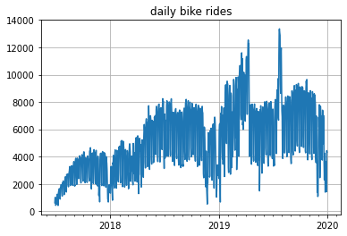

```python
fig, ax = plt.subplots()
ax.plot('date', 'ride_cnt', data=bike_daily_cnt_df)

years = mdates.YearLocator()   # every year
months = mdates.MonthLocator()  # every month
years_fmt = mdates.DateFormatter('%Y')
# format the ticks
plt.title('daily bike rides')
ax.xaxis.set_major_locator(years)
ax.xaxis.set_major_formatter(years_fmt)
ax.xaxis.set_minor_locator(months)
ax.format_xdata = mdates.DateFormatter('%Y-%m-%d')
ax.grid(True)
plt.show()
```

```python
# check missing data, there should be 917 days.
len(bike_daily_cnt_df)
```

```
917
```

**Investigate the change points**

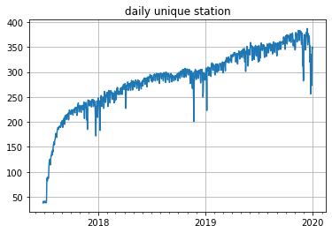

```python
## check station count
station_cnt = bike_df.groupby(['date'])['start_station_id'].nunique().reset_index()
fig, ax = plt.subplots()
ax.plot('date', 'start_station_id', data=station_cnt)
years = mdates.YearLocator()   # every year
months = mdates.MonthLocator()  # every month
years_fmt = mdates.DateFormatter('%Y')
plt.title('daily unique station')
ax.xaxis.set_major_locator(years)
ax.xaxis.set_major_formatter(years_fmt)
ax.xaxis.set_minor_locator(months)
ax.format_xdata = mdates.DateFormatter('%Y-%m-%d')
ax.grid(True)
plt.show()
```

**The drop happened on Apr 14th, maybe a lot of bikes got removed from the docks**

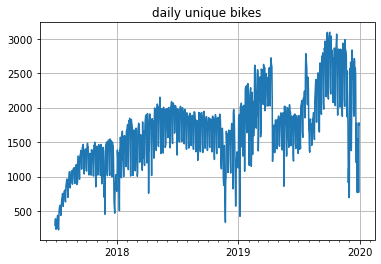

```python
## check bike count
bike_cnt = bike_df.groupby(['date'])['bike_id'].nunique().reset_index()
fig, ax = plt.subplots()
ax.plot('date', 'bike_id', data=bike_cnt)
years = mdates.YearLocator()   # every year
months = mdates.MonthLocator()  # every month
years_fmt = mdates.DateFormatter('%Y')
plt.title('daily unique bikes')
ax.xaxis.set_major_locator(years)
ax.xaxis.set_major_formatter(years_fmt)
ax.xaxis.set_minor_locator(months)
ax.format_xdata = mdates.DateFormatter('%Y-%m-%d')
ax.grid(True)
plt.show()
```

**look at the drop by user type: we see similar drops in both non-subscriber and subscriber group**

```python
from pandas.tseries.holiday import USFederalHolidayCalendar as calendar
cal = calendar()
holidays = cal.holidays(start=min(bike_daily_cnt_df.date), end=max(bike_daily_cnt_df.date))
```

```python
bike_daily_cnt_df_user = bike_df.groupby(['date','user_type']).size().reset_index()
bike_daily_cnt_df_user = bike_daily_cnt_df_user.rename(columns={0: "ride_cnt"})
bike_daily_cnt_df_user['weekOfday'] = pd.to_datetime(bike_daily_cnt_df_user['date']).dt.weekday
bike_daily_cnt_df_user['is_weekend'] = np.where(bike_daily_cnt_df_user['weekOfday']<5, 0, 1)
bike_daily_cnt_df_user['is_holiday'] = np.where(bike_daily_cnt_df_user['date'].isin(holidays.date.tolist()), 1, 0)
bike_daily_cnt_df_user['month'] = pd.to_datetime(bike_daily_cnt_df_user['date']).dt.month
all_data_user =  bike_daily_cnt_df_user.merge(weather_daily,how='left',left_on='date',right_on = 'day')
all_data_user.drop(['DATE','day'],axis = 1, inplace=True)
```

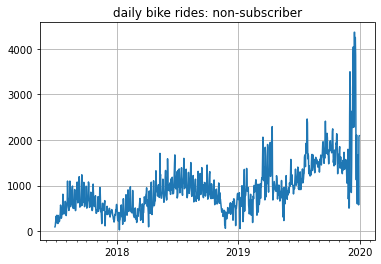

```python
fig, ax = plt.subplots()
ax.plot('date', 'ride_cnt', data=bike_daily_cnt_df_user[bike_daily_cnt_df_user['user_type']=='Customer'])
years = mdates.YearLocator()   # every year
months = mdates.MonthLocator()  # every month
years_fmt = mdates.DateFormatter('%Y')
# format the ticks
plt.title('daily bike rides: non-subscriber')
ax.xaxis.set_major_locator(years)
ax.xaxis.set_major_formatter(years_fmt)
ax.xaxis.set_minor_locator(months)
ax.format_xdata = mdates.DateFormatter('%Y-%m-%d')
ax.grid(True)
plt.show()
```

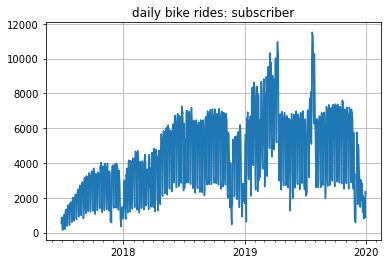

```python
fig, ax = plt.subplots()
ax.plot('date', 'ride_cnt', data=bike_daily_cnt_df_user[bike_daily_cnt_df_user['user_type']=='Subscriber'])
years = mdates.YearLocator()   # every year
months = mdates.MonthLocator()  # every month
years_fmt = mdates.DateFormatter('%Y')
# format the ticks
plt.title('daily bike rides: subscriber')
ax.xaxis.set_major_locator(years)
ax.xaxis.set_major_formatter(years_fmt)
ax.xaxis.set_minor_locator(months)
ax.format_xdata = mdates.DateFormatter('%Y-%m-%d')
ax.grid(True)
plt.show()
```

**We suspect the daily ride count depends on weekday/weekend, holiday, month, deviation from normal temperature, temperature and precipitation. We check the average ride count against these variables.**

```python
bike_daily_cnt_df['weekOfday'] = pd.to_datetime(bike_daily_cnt_df['date']).dt.weekday
bike_daily_cnt_df['is_weekend'] = np.where(bike_daily_cnt_df['weekOfday']<5, 0, 1)
holiday_lst = [pd.to_datetime('2017-11-01', format='%Y-%m-%d')]
bike_daily_cnt_df['is_holiday'] = np.where(bike_daily_cnt_df['date'].isin(holidays.date.tolist()), 1, 0)
bike_daily_cnt_df['month'] = pd.to_datetime(bike_daily_cnt_df['date']).dt.month
```

```python
all_data = bike_daily_cnt_df.merge(weather_daily,how='left',left_on='date',right_on = 'day')
all_data.drop(['DATE','day'],axis = 1, inplace=True)
```

- For subscribers, the weekday volumes are similar, and weekend volumes are a lot lower. For our feature, we will likely drop week of day and just keep is_weekend.  
- For non-subscribers, the volumes are more evenly distributed over a week  
- For subscribers, ride count on holiday is significantly lower, and for non-subscribers, the rider count is not affected by holidays too much  
- For subscribers, ride count in the summer months is lower, where for non-subscriber, we see an oppostie trend

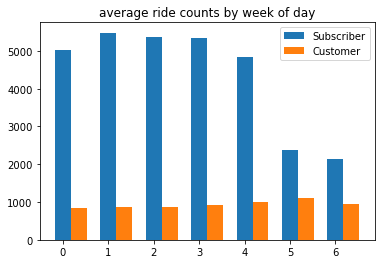

```python
fig, ax = plt.subplots()
width = 0.35         # the width of the bars
p1 = ax.bar(all_data_user[all_data_user['user_type']=='Subscriber'].groupby(['weekOfday']).agg({'ride_cnt':np.mean}).index,
            all_data_user[all_data_user['user_type']=='Subscriber'].groupby(['weekOfday']).agg({'ride_cnt':np.mean})['ride_cnt'],
            width)
p2 = ax.bar(all_data_user[all_data_user['user_type']=='Customer'].groupby(['weekOfday']).agg({'ride_cnt':np.mean}).index + width,
            all_data_user[all_data_user['user_type']=='Customer'].groupby(['weekOfday']).agg({'ride_cnt':np.mean})['ride_cnt'],
            width)
ax.legend((p1[0], p2[0]), ('Subscriber', 'Customer'))
plt.title('average ride counts by week of day')
plt.show()
```

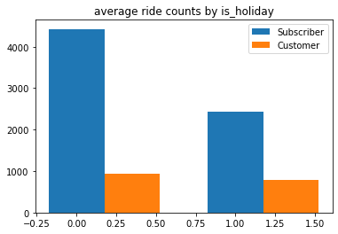

```python
fig, ax = plt.subplots()
width = 0.35         # the width of the bars
p1 = ax.bar(all_data_user[all_data_user['user_type']=='Subscriber'].groupby(['is_holiday']).agg({'ride_cnt':np.mean}).index,
            all_data_user[all_data_user['user_type']=='Subscriber'].groupby(['is_holiday']).agg({'ride_cnt':np.mean})['ride_cnt'],
            width)
p2 = ax.bar(all_data_user[all_data_user['user_type']=='Customer'].groupby(['is_holiday']).agg({'ride_cnt':np.mean}).index + width,
            all_data_user[all_data_user['user_type']=='Customer'].groupby(['is_holiday']).agg({'ride_cnt':np.mean})['ride_cnt'],
            width)
ax.legend((p1[0], p2[0]), ('Subscriber', 'Customer'))
plt.title('average ride counts by is_holiday')
plt.show()
```

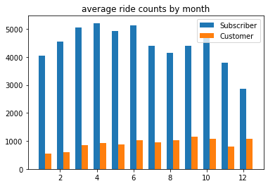

```python
fig, ax = plt.subplots()
width = 0.35         # the width of the bars
p1 = ax.bar(all_data_user[all_data_user['user_type']=='Subscriber'].groupby(['month']).agg({'ride_cnt':np.mean}).index,
            all_data_user[all_data_user['user_type']=='Subscriber'].groupby(['month']).agg({'ride_cnt':np.mean})['ride_cnt'],
            width)
p2 = ax.bar(all_data_user[all_data_user['user_type']=='Customer'].groupby(['month']).agg({'ride_cnt':np.mean}).index + width,
            all_data_user[all_data_user['user_type']=='Customer'].groupby(['month']).agg({'ride_cnt':np.mean})['ride_cnt'],
            width)
ax.legend((p1[0], p2[0]), ('Subscriber', 'Customer'))
plt.title('average ride counts by month')
plt.show()
```

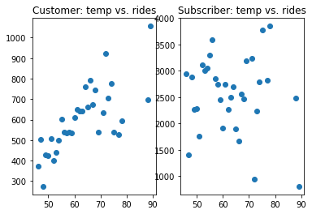

```python
temp_ride = all_data_user.groupby(['user_type','DAILYAverageDryBulbTemp']).agg({'ride_cnt':np.mean}).reset_index()
fig, (ax1, ax2) = plt.subplots(1, 2)
ax1.set_title('Customer: temp vs. rides')
ax2.set_title('Subscriber: temp vs. rides')
ax1.scatter(temp_ride[temp_ride['user_type']=='Customer']['DAILYAverageDryBulbTemp'],
           temp_ride[temp_ride['user_type']=='Customer']['ride_cnt'])
ax2.scatter(temp_ride[temp_ride['user_type']=='Subscriber']['DAILYAverageDryBulbTemp'],
           temp_ride[temp_ride['user_type']=='Subscriber']['ride_cnt'])
plt.show()
```

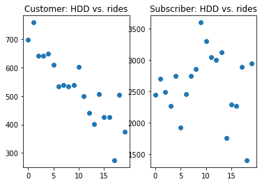

```python
temp_ride = all_data_user.groupby(['user_type','DAILYHeatingDegreeDays']).agg({'ride_cnt':np.mean}).reset_index()
fig, (ax1, ax2) = plt.subplots(1, 2)
ax1.set_title('Customer: HDD vs. rides')
ax2.set_title('Subscriber: HDD vs. rides')
ax1.scatter(temp_ride[temp_ride['user_type']=='Customer']['DAILYHeatingDegreeDays'],
           temp_ride[temp_ride['user_type']=='Customer']['ride_cnt'])
ax2.scatter(temp_ride[temp_ride['user_type']=='Subscriber']['DAILYHeatingDegreeDays'],
           temp_ride[temp_ride['user_type']=='Subscriber']['ride_cnt'])
plt.show()
```

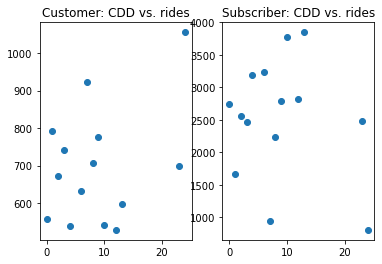

```python
temp_ride = all_data_user.groupby(['user_type','DAILYCoolingDegreeDays']).agg({'ride_cnt':np.mean}).reset_index()
fig, (ax1, ax2) = plt.subplots(1, 2)
ax1.set_title('Customer: CDD vs. rides')
ax2.set_title('Subscriber: CDD vs. rides')
ax1.scatter(temp_ride[temp_ride['user_type']=='Customer']['DAILYCoolingDegreeDays'],
           temp_ride[temp_ride['user_type']=='Customer']['ride_cnt'])
ax2.scatter(temp_ride[temp_ride['user_type']=='Subscriber']['DAILYCoolingDegreeDays'],
           temp_ride[temp_ride['user_type']=='Subscriber']['ride_cnt'])
plt.show()
```

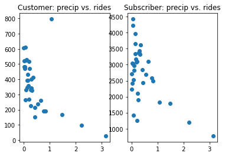

```python
temp_ride = all_data_user.groupby(['user_type','DAILYPrecip']).agg({'ride_cnt':np.mean}).reset_index()
fig, (ax1, ax2) = plt.subplots(1, 2)
ax1.set_title('Customer: precip vs. rides')
ax2.set_title('Subscriber: precip vs. rides')
ax1.scatter(temp_ride[temp_ride['user_type']=='Customer']['DAILYPrecip'],
           temp_ride[temp_ride['user_type']=='Customer']['ride_cnt'])
ax2.scatter(temp_ride[temp_ride['user_type']=='Subscriber']['DAILYPrecip'],
           temp_ride[temp_ride['user_type']=='Subscriber']['ride_cnt'])
plt.show()
```

## Modeling

**Adding dummy variabes**

```python
month_df=pd.get_dummies(all_data_user['month'],prefix='m',drop_first=True)
final_df = all_data_user.join(month_df)
final_df.drop(['weekOfday','month','DAILYDeptFromNormalAverageTemp',
               'DAILYHeatingDegreeDays','DAILYCoolingDegreeDays'],axis=1,inplace=True)
```

```python
final_df = final_df[final_df['date']<=pd.to_datetime('2018-05-23', format='%Y-%m-%d')]
subscriber_df = final_df[final_df['user_type']=='Subscriber']
customer_df = final_df[final_df['user_type']=='Customer']
```

**There is likely non-linear relationships between weather and ride count. Therefore, we will fit a random forest model to capture the non-linear patterns. However, there does seem to be a linear trend in the bike ride count. Ideally, we should detrend the series before fitting a random forest model. (How one would do it is as below)**

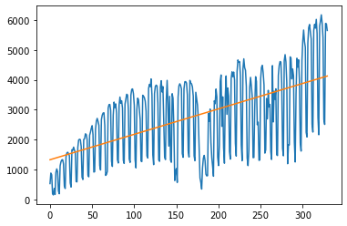

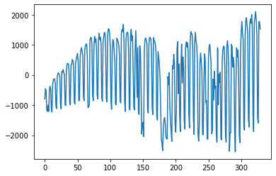

```python
from sklearn.linear_model import LinearRegression
X = [i for i in range(0, len(subscriber_df))]
X = np.reshape(X, (len(X), 1))
y = subscriber_df.ride_cnt
model = LinearRegression()
model.fit(X, y)
## calculate trend
trend = model.predict(X)
# plot trend
plt.plot(y.reset_index().ride_cnt)
plt.plot(trend)
plt.show()
# detrend
detrended_sub = [y.reset_index().ride_cnt[i]-trend[i] for i in range(0, len(subscriber_df))]
# plot detrended
plt.plot(detrended_sub)
plt.show()
```

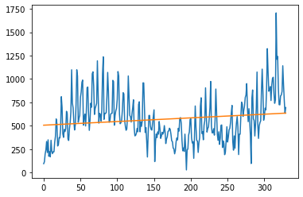

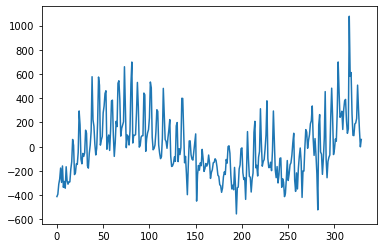

```python
X = [i for i in range(0, len(customer_df))]
X = np.reshape(X, (len(X), 1))
y = customer_df.ride_cnt
model = LinearRegression()
model.fit(X, y)
## calculate trend
trend = model.predict(X)
# plot trend
plt.plot(y.reset_index().ride_cnt)
plt.plot(trend)
plt.show()
# detrend
detrended_cus = [y.reset_index().ride_cnt[i]-trend[i] for i in range(0, len(customer_df))]
# plot detrended
plt.plot(detrended_cus)
plt.show()
```

```python
subscriber_df['detrended_ride_cnt'] = detrended_sub
customer_df['detrended_ride_cnt'] = detrended_cus
```

**Random forest**

**Like indicated before, we have very limited data to fit a model and conduct proper backtest. But the model importance corroborates what we observed in our exploratory analysis. For subscribers, is_weekend is the most important factor. Precipitation is more important than temperature. For non-subsribers, temperature is more important than precipitation.**

Subscriber

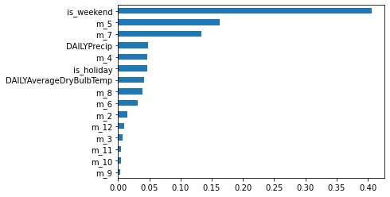

```python
from sklearn.ensemble import RandomForestRegressor
from sklearn import metrics
rf = RandomForestRegressor(n_estimators=100)
X_train = subscriber_df.reset_index().fillna(method='ffill').iloc[:,4:19]
y_train = subscriber_df.reset_index().ride_cnt
rf.fit(X_train, y_train)
y_pred = rf.predict(X_train)
importances_rf = pd.Series(data=rf.feature_importances_ , index= X_train.columns)
# sorted importance values:
importance_sorted=importances_rf.sort_values()
importance_sorted.plot(kind="barh");
```

```python
print('Mean Absolute Error:', metrics.mean_absolute_error(y_train, y_pred))
print('Root Mean Squared Error:', np.sqrt(metrics.mean_squared_error(y_train, y_pred)))
print('Mean Absolute Percentage Error:',np.mean(np.abs((y_train-y_pred)/y_train)))
```

```
Mean Absolute Error: 190.19175330031922
Root Mean Squared Error: 306.0463678294874
Mean Absolute Percentage Error: 0.11569324111449011
```

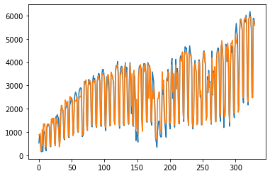

```python
plt.plot(y_train)
plt.plot(y_pred)
```

Non-subscriber

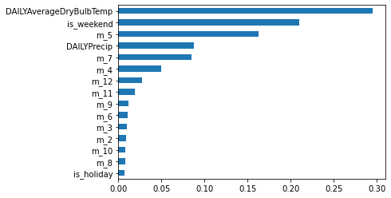

```python
from sklearn.ensemble import RandomForestRegressor
from sklearn import metrics
rf = RandomForestRegressor(n_estimators=100)
X_train = customer_df.reset_index().fillna(method='ffill').iloc[:,4:19]
y_train = customer_df.reset_index().ride_cnt
rf.fit(X_train, y_train)
y_pred = rf.predict(X_train)
importances_rf = pd.Series(data=rf.feature_importances_ , index= X_train.columns)
# sorted importance values:
importance_sorted=importances_rf.sort_values()
importance_sorted.plot(kind="barh");
```

```python
print('Mean Absolute Error:', metrics.mean_absolute_error(y_train, y_pred))
print('Root Mean Squared Error:', np.sqrt(metrics.mean_squared_error(y_train, y_pred)))
print('Mean Absolute Error:',np.mean(np.abs((y_train-y_pred)/y_train)))
```

```
Mean Absolute Error: 56.36887538622993
Root Mean Squared Error: 80.43597554203659
Mean Absolute Error: 0.12217548737425993
```